# A Representative Sample of Australian Participant’s Attitudes Towards the COVIDSafe App.

Dr Paul Garrett$^1$, Mr Joshua White$^1$, A/Prof Daniel Little$^1$, A/Prof Amy Perfors$^1$, Prof Yoshihisa Kashima$^1$, Prof Stephan Lewandowsky$^2$, & Prof Simon Dennis$^1$

$^1$Complex Human Data Hub, School of Psychological Sciences, The University of Melbourne.

$^2$School of Psychological Sciences, The University of Bristol.

Data collected: 7/5/2020. Initial upload: 8/5/2020/ (Edited 10/5/2020).

# Background

The novel coronavirus or COVID-19 was declared a pandemic by the World Health Organization on March 11th, 2020 (World Health Organization, 2020). The COVID-19 virus transmits early in its life cycle relative to other coronaviruses, (e.g., SARS), during which time many individuals present as asymptomatic (Zhou et al., 2020). In many countries, including the United States and the UK, COVID-19 has spread at an exponential rate (see Figure 1). As of 07/05/2020, the number of deaths attributed to COVID-19 worldwide stands at 263,501.

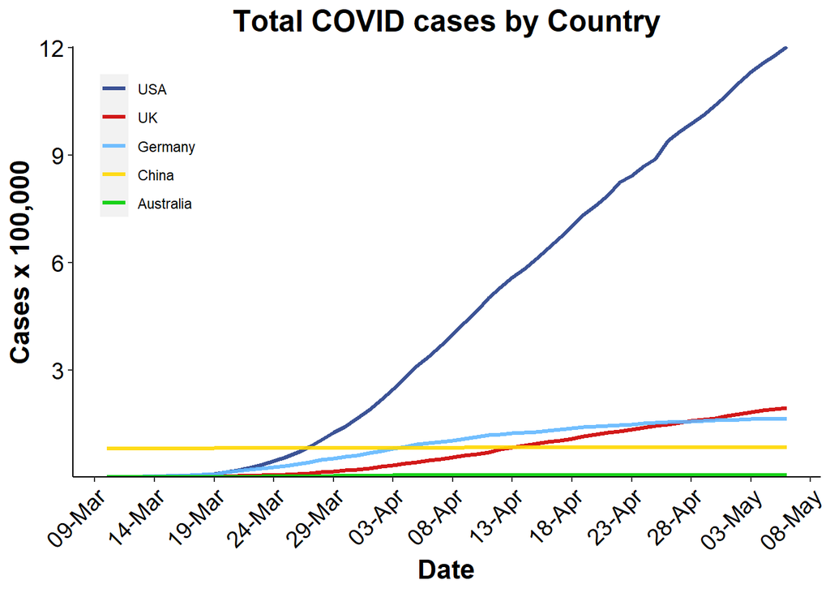

In Australia, lock down measures and physical distancing have already had an impact on the spread of COVID-19, slowing the rate of transmission and helping to “flatten the curve” - the process of slowing the exponential transmission rate of the virus (blue line, Figure 2). Fortunately, Australia’s intensive care units have not been overwhelmed by COVID-19 cases, ensuring that those who show signs of respiratory distress can get access to life saving interventions (red line, Figure 2).

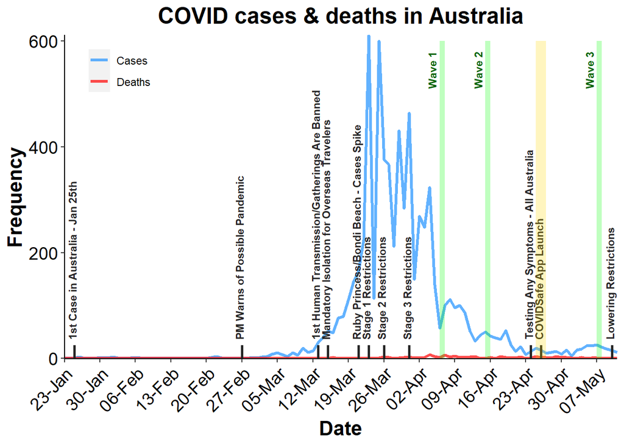

Figure 2. COVID-19 cases and deaths in Australia. Key dates relating to COVID-19 and Australian Government policies are labeled. Waves 1, 2, and 3 of the current study are illustrated in green. COVIDSafe app launch is highlighted in yellow.

Although Australia is working hard to flatten the curve, it is unclear whether current government policies will be effective as non-essential individuals re-enter the workforce and face the prospect of a second outbreak of COVID-19, (e.g., Singapore). The moderate to high transmissibility of this virus has required governments to consider technological solutions to prevent further transmissions. Indeed, the nature of the COVID-19 pandemic may require governments to use big data technologies to help contain its spread (Bonsall, Parker, & Fraser, 2020).

On April 26th 2020, the Australian Government released its own contact tracing app: ‘COVIDSafe’. The COVIDSafe app uses Bluetooth technology to establish an anonymous contact registry to identify which phones (and people) you have been collocated with and for how long. If a user voluntarily self-identifies as testing positive to COVID-19, they may upload their contact registry to a centralised repository only accessible by the Health Department. Contact tracers will then distribute alerts to those individuals who have been collocated with this individual for a period of 15 minutes or longer within the time-frame that individual was considered to be contagious. Every 21 days, your encrypted COVIDSafe ids are deleted off your phone, preserving your privacy. Only data from the past 21 days can be uploaded via the app if you report as testing positive to COVID-19.

The effectiveness of the COVIDSafe collocation tracking relies on the willingness of the population to support such measures, implying that government policy-making should be informed by the likelihood of public compliance. Estimates of the necessary compliance for COVIDSafe to work effectively range from 40-60% of the population. Gaining the social license - broad community acceptance beyond formal legal requirements - for collocation tracking requires the perceived public health benefits to outweigh concerns of personal privacy, security, and any potential risk of harm.

# Results

## Status of the initial data collected

The results presented in this preliminary report represent a snapshot from 536 participants collected on the 05-07-2020 during the third wave of data collection for the project ‘Establishing the social licence for Government tracking in Australia’.

The reported representative sample was gathered through the data collection platform Dynata. 500 participants reported their demographics and their perceived severity of the COVID-19 outbreak in Australia and around the world. They then viewed a description of the COVIDSafe app, before answering questions about their attitudes towards the app. Finally, participants responded to questions about the introduction of a theoretical immunity passport and their world views.

### Notes on cleaning the data.

1. Of the initial 536 participants collected, 7 participants were removed prior to analysis for indicating a country of residence other than Australia.
2. A further 2 participants were removed prior to analysis for indicating they were below the age of 18.
3. An additional 67 participants did not pass the attention check.
4. Finally, 21 participants began and did not complete the survey.

After cleaning the data for the above participants, the final sample at analysis was 439 participants.

## Descriptive Statistics

Gender was evenly divided between men (49%) and women (51%), and 93% of participants reported that they currently use a smartphone. Within our sample, participants most frequently reported as having a university education (49%) or a higher school education (41%). Ages ranged from 18 years to 84 years (M = 47 years, SD = 17 years). The distribution of reported ages was roughly uniform within the age range 20–80, and under represented for ages 80+.

| Gender identification: Percentages | Gender identification: Percentages Percent |
| --- | --- |
| Gender |  |
| Men | 49.0 |
| Women | 50.8 |
| Other | 0.2 |
| Prefer not to say |  |
| #Total cases | 439 |

| Level of education: Percentages | Level of education: Percentages Percent |
| --- | --- |
| Education |  |
| Did Not Graduate High School | 10.5 |
| Graduated High School | 40.5 |
| Graduated University | 49.0 |
| #Total cases | 439 |

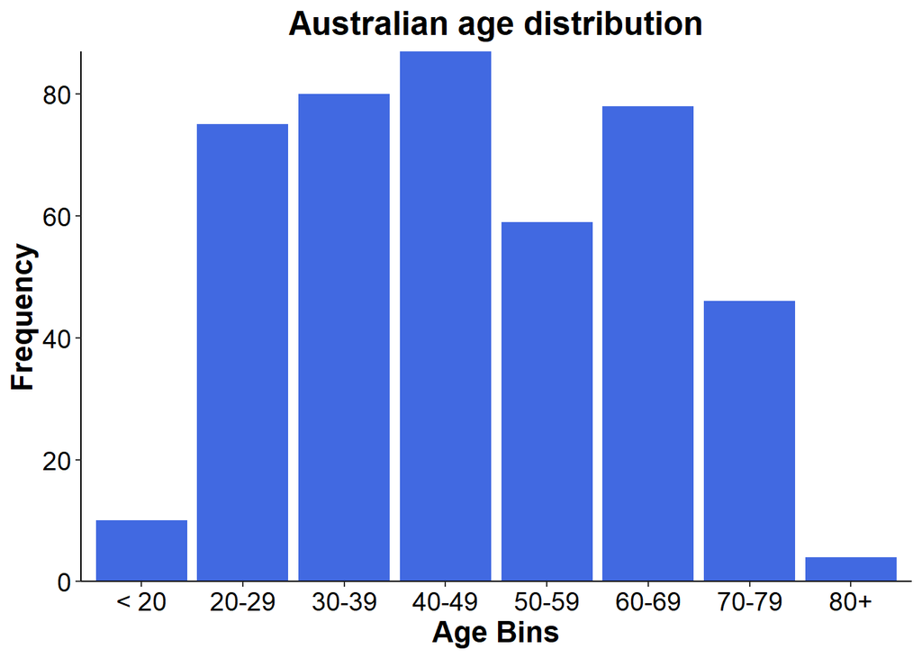

## Impacts of COVID

Participants reported as being under lock down for an average of 24 (SD = 25) days, with the most frequent amount of time in lock down reported as 0 days (n = 127, 29%). 17% of participants reported as having lost their job due to COVID-19. The most common source of COVID-19 information came from TV (57%) and newspaper (15%), followed by social media (13%). Of the 439 participants, 7 (2%) reported that they had tested positive with COVID-19, and 36 (8%) indicated they knew someone who had tested positive with COVID-19.

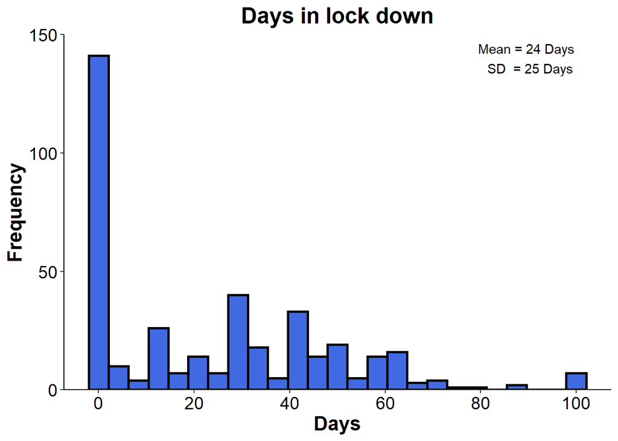

| I have lost my job: Percentages | I have lost my job: Percentages Percent |
| --- | --- |
| I lost my job |  |
| No | 82.9 |
| Yes | 17.1 |
| #Total cases | 439 |

| Information source: Percentages | Information source: Percentages Percent |
| --- | --- |
| Information source |  |
| Newspaper (printed or online) | 15.5 |
| Social media | 12.8 |
| Friends/family | 2.5 |
| Radio | 5.7 |
| Television | 57.2 |
| Other | 2.7 |
| Do not follow | 3.6 |
| #Total cases | 439 |

| Somebody I know tested positive for COVID-19: Percentages | Somebody I know tested positive for COVID-19: Percentages Percent |
| --- | --- |
| Tested pos someone I know |  |
| No | 91.8 |
| Yes | 8.2 |
| #Total cases | 439 |

## Compliance with COVID Restrictions

When asked what percentage of the population was complying with government policies regarding social distancing, the average estimate was 73% (SD = 21%; see below figure). When asked if they were complying with Governmental lockdown policies, 72% of participants indicated that they were either completely complying or going beyond policy suggestions. 0% indicated they were not complying at all, while 28% indicated some degree of partial compliance.

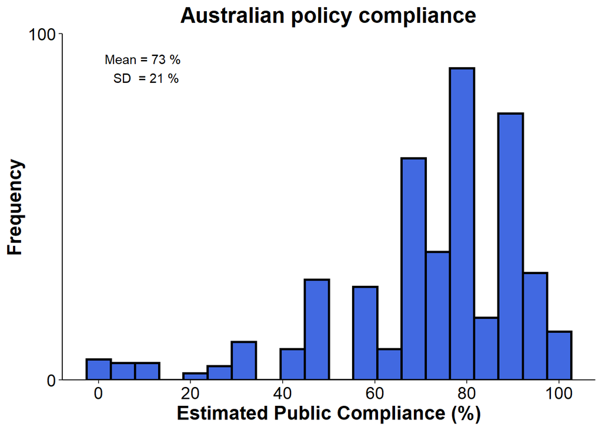

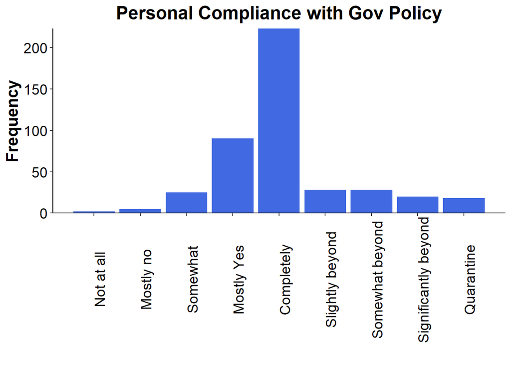

## Perceived Risk of COVID

We asked participants about the perceived risk COVID-19 poses for themselves and those around them. Responses were made on a likert scale with values:

1. Not at all,
2. Slightly,
3. Somewhat,
4. Very,
5. Extremely.

When asked about COVID-19 within the Australian population, participants most frequently reported the virus to be moderate in severity and that the virus posed a ‘somewhat’ or ‘very’ harmful risk to their personal health. 95% of participants reported the virus to be at least ‘a little severe’ (2) for the population and at least ‘a little harmful’ (2) to their health.

When asked about their concern over testing positive to COVID-19, responses were skewed and participants reported as being less concerned than during previous assessments. When asked about their concern over someone they know testing positive to COVID-19, participants responses were negatively skewed. This indicates a bias towards concern over others in their community, such as the elderly or nurses and doctors, testing positive to COVID-19. This trend has remained stable across our three waves of data collection. A strong correlation was observed between concern for others and concern for self (r = .79), and between risk of personal harm and concern for self (r = .64).

Finally, we asked participants to report their estimates on the number of fatalities across a range of countries with moderate-to-high media coverage in Australia. Responses were made on a sliding scale ranging from 0 - 50,000; results are reported in estimated deaths per 1000 (see violin plot).

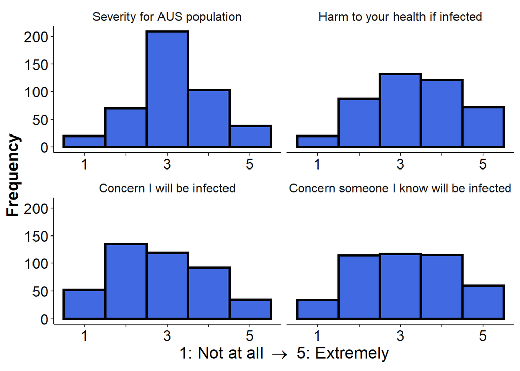

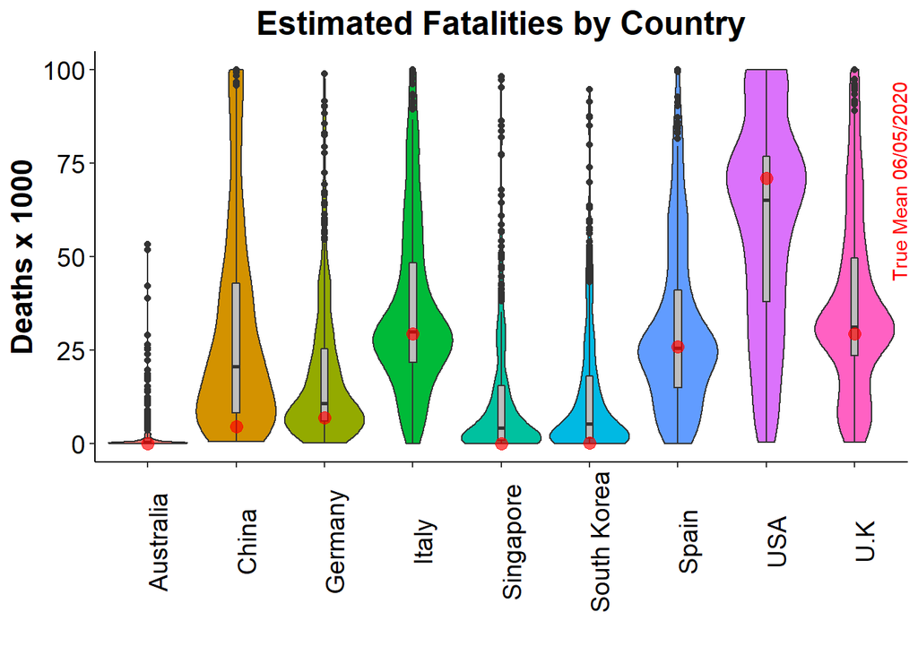

# The COVIDSafe App

## COVIDSafe - App Perception

The Australian Government has recently released the COVIDSafe smartphone app to trace the spread of COVID-19. We asked participants to assess their understanding of the COVIDSafe app, before presenting them a factual description of the app.

When asked what technology does the COVIDSafe smartphone app use, **60% of participants responded Bluetooth**, 19% responded Location data, 5% responded Mobile phone tower, and 16% responded that they did not know. In a later section of the survey, we ask if participants have downloaded the COVIDSafe app - we will now report the same results broken down by those who have and have not downloaded the app.

Of the 439 participants, **44% did download the COVIDSafe app**. Of these participants, 81% reported that the app uses Bluetooth, 11% location data, 4% mobile network data, and 4% reported that they did not know.

Of the 439 participants, **56% did not download the COVIDSafe app**. Of these participants, 43% reported that the app uses Bluetooth, 25% location data, 6% mobile network data, and 26% reported they did not know.

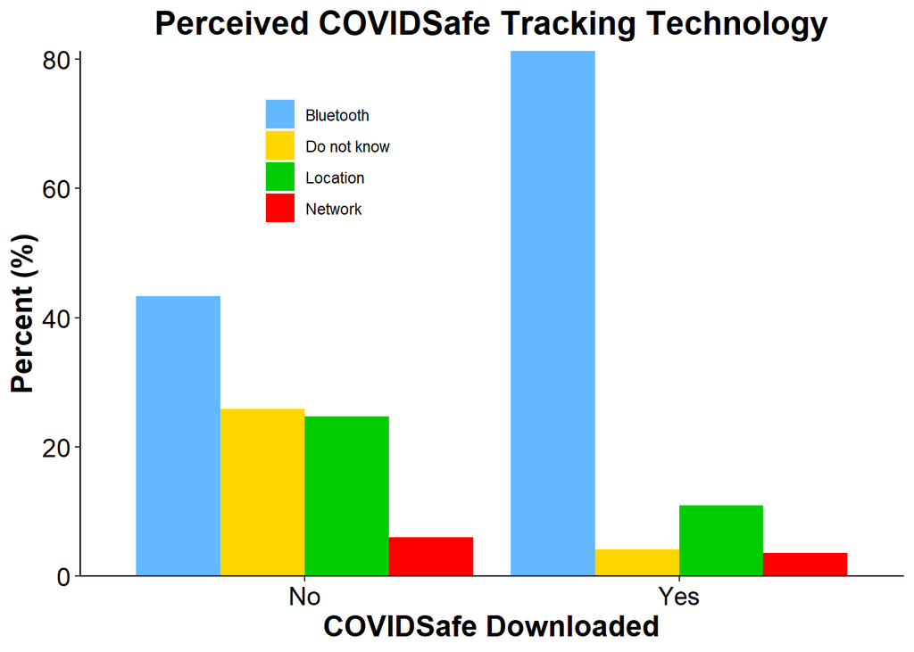

## COVIDSafe - App Description

Participants were provided the following description of the COVIDSafe app before they proceeded to answer the remaining survey questions.

“The COVID-19 pandemic has rapidly become a worldwide threat. Containing the virus’ spread is essential to minimise the impact on the healthcare system, the economy, and save many lives. The Australian Government has recently released the COVIDSafe smartphone app to help identify and contact those who may have been exposed to people with COVID-19. **The use of this app is completely voluntary, but the government has explicitly stated that easing social distancing restrictions depends at least in part on the degree of community uptake of this voluntary app.** This is because, the more people that download and use this app the more effectively it will help to contain the spread of COVID-19. **The app works with bluetooth and no location data is collected**: when two people are near each other, their phones connect and keep a record of all these connections. If a person is later identified as being infected, that person may **voluntarily upload their bluetooth contacts to a secure server accessible only to the Health Department of the Australian Government. This data would only be used by the Health Department of the Australian Government to contact those who might have been exposed to COVID-19.**”

## COVIDSafe - The Current Effective Use

44% of participants downloaded the COVIDSafe app, however, downloads do not always translate to effective usage. We examine whether these participants:

1. Are registered on the app?
   - Yes 90%
   - No 4%
   - Don’t know 6%
2. Keep the app installed on their phone?
   - Yes 96%
   - No 4%
3. Keep Bluetooth on?
   - Yes 77%
   - Only when I leave the house 15%
   - No 5%
   - I don’t know 3%
4. Have the app downloaded, are registered and have bluetooth switched on?
   - Yes 76%
   - Only when I leave the house 15%
   - No 7%
   - I don’t know 3%
5. Would upload their data if they tested positive to COVID-19?
   - Yes 99%
   - No 1%
6. Have tried to share the app with others?
   - Yes 58%
   - No 42%

Our findings suggest that up to 91% of COVIDSafe app users are registered & have bluetooth switched on when they leave the house and interact with members of the general public. Although only 2% of our sample have received a COVID-19 diagnosis, 99% indicated they would upload their contact information through COVIDSafe if they were diagnosed with the virus. 58% of COVIDSafe users have tried to share the app with others.

## COVIDSafe - Reasons for downloading the app

It is important to understand why individuals choose to download and use the COVIDSafe app. Below, we present the results of a rank ordered question set where participants indicated from most-to-least those factors that convinced them to download COVIDSafe. Options included:

1. To return to normal activities
2. To protect my health
3. To protect the health of others
4. To follow Government recommendations
5. To help the economy

In general, we observe that participants were most motivated to download the app so as to return to normal activities, and then to protect their health and the health of others. Participants were least motivated by the prospect of helping the economy, and only slightly more motivated by Government recommendations.

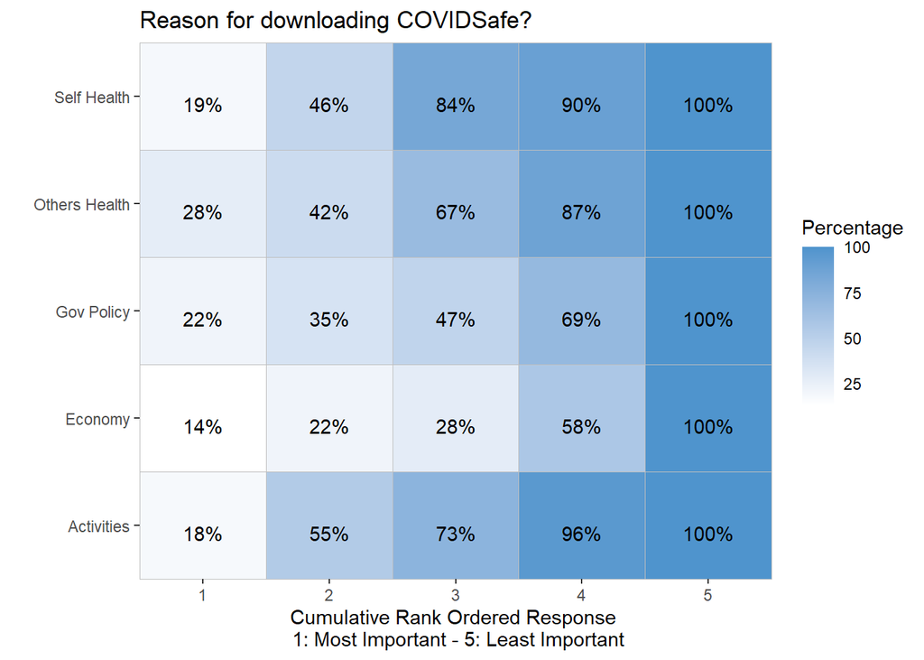

### COVIDSafe - Downloading due to others

Individuals within the public domain may convince others to download the COVIDSafe app. Here, we asked participants to rank order those individuals who most convinced them to download the COVIDSafe app. Responses included:

1. The Prime Minister
2. Other politicians
3. Government advertising
4. Friend or family
5. Other public figure
6. Scientist or Researcher
7. Nobody, I did not need convincing

Our findings indicate that Government advertising and motivation provided by the Prime Minister & Other Politicians provided 58% of the most important motivation for downloading the COVIDSafe app.

After receiving some initial motivation, 33% of participants did not require further convincing to download the app, possibly an indication of early app adopters. Importantly, only 6% of participants reported that they did not need initial external motivation, highlighting the importance of clear and effective communication regarding the COVIDSafe app and the importance of contact tracing.

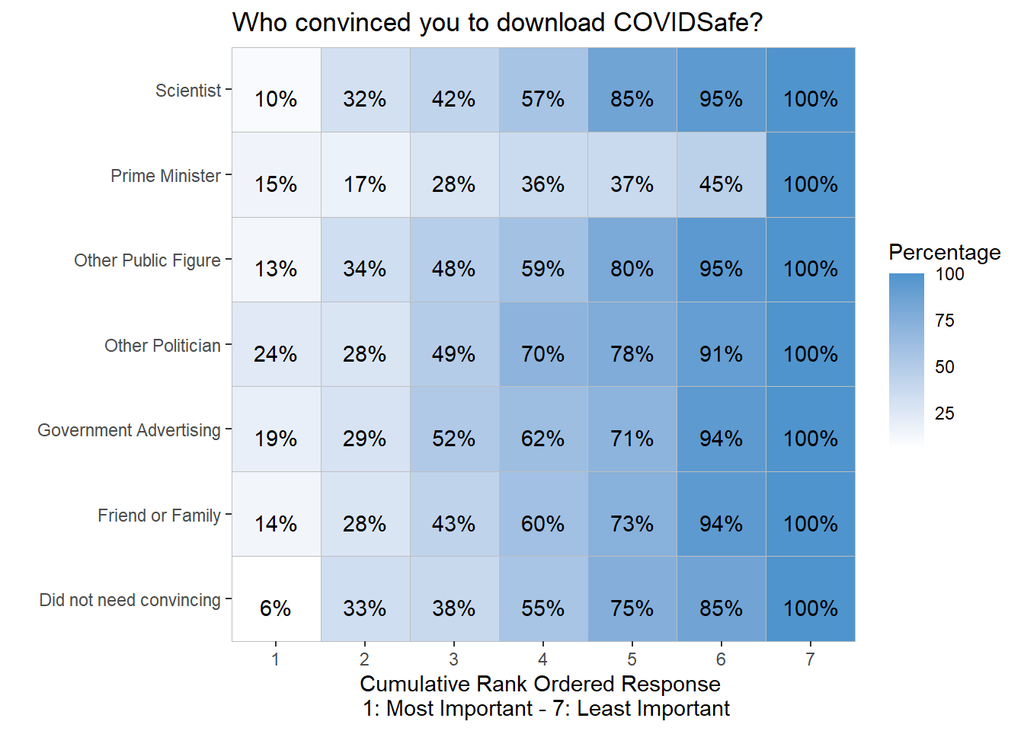

# COVIDSafe - Non Users & Future Users

In this next section, we examine responses from the 56% of individuals who have not yet downloaded the COVIDSafe app. This analysis will cover two sub-groups: those who intend to download the app in the future, and those who never intend to download the COVIDSafe app.

## COVIDSafe - Non Users who intend to download the app

Our findings show that 28% (n = 68) of non-app users (15% total participants) intend to download the app in the future. When asked if they planned to upload their data through the app if they tested positive to COVID-19, 68 of the 68 participants indicated that they would.

There are many reasons why individuals may yet download the app. We asked participants to rank order eight potential reasons for not having yet download the app from most applicable to least applicable. Responses included:

1. I have not had time
2. I have not left the house yet
3. Technical issues
4. I am waiting to see if enough people download the app for it to be effective
5. I have been considering the pros and cons of downloading the app
6. It has not crossed my mind
7. I am waiting on Government legislation on the use of the app’s data
8. I do not know how to download the app

The following figure provides the rank ordered responses to the above options from most applicable (1) to least applicable (8).

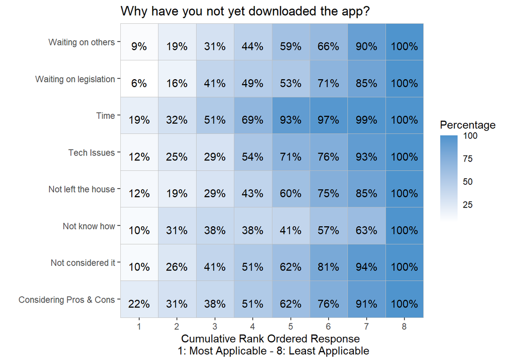

## COVIDSafe - Non Users who do not intend to download the app

Our findings show that 72% (n = 179) of non-app users (41% total participants) intend to not download the app in the future, however, 51 of these individuals would download the app if appropriate privacy protections were legislated by parliament.

There are many reasons why individuals may not wish to download the app. We asked participants to rank order seven possible responses:

1. I am concerned about privacy
2. I don’t trust the Government with my data
3. I am worried about battery usage on my phone
4. I don’t think it’s going to be effective
5. I am worried about normalising Government tracking
6. I am concerned about the Government encroaching on civil liberties
7. I don’t know how to download it

The following figure provides the rank ordered responses to the above options from most applicable (1) to least applicable (7).

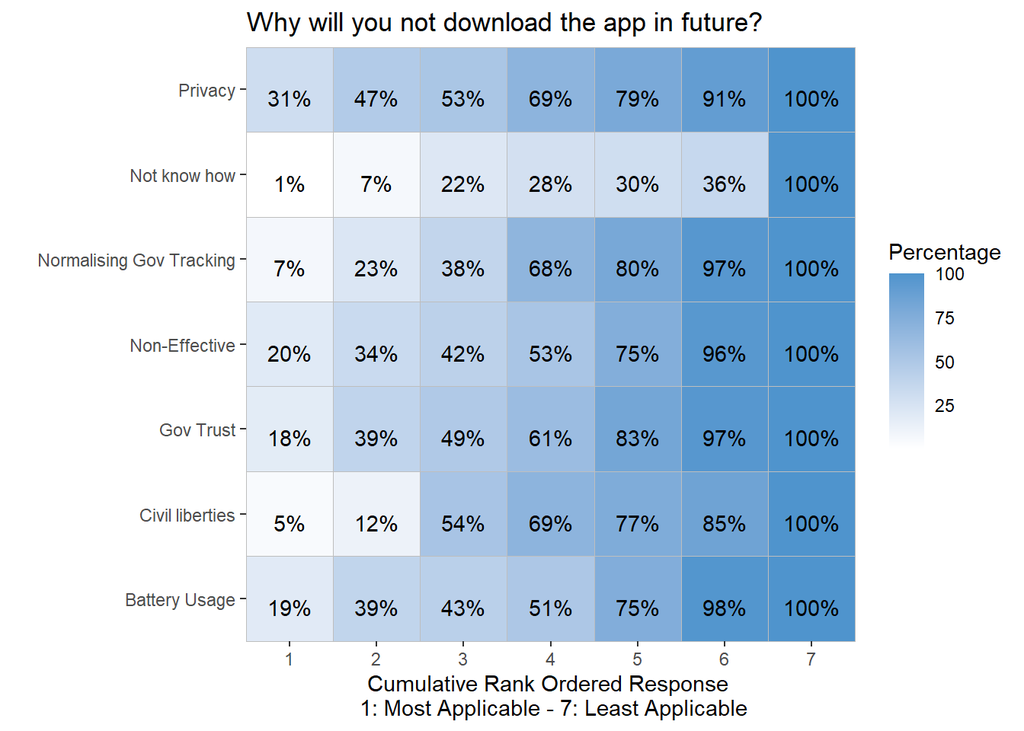

### COVIDSafe - Who influenced you to not download the app?

Similarly, people my be influenced by other individuals into not downloading the COVIDSafe app. We asked participants to rank order the following individuals who may have convinced them **not** to download the app:

1. The Prime Minister
2. Other politicians
3. Government advertising
4. Friend or family
5. Other public figure
6. Scientist or Researcher
7. Nobody, I did not need convincing

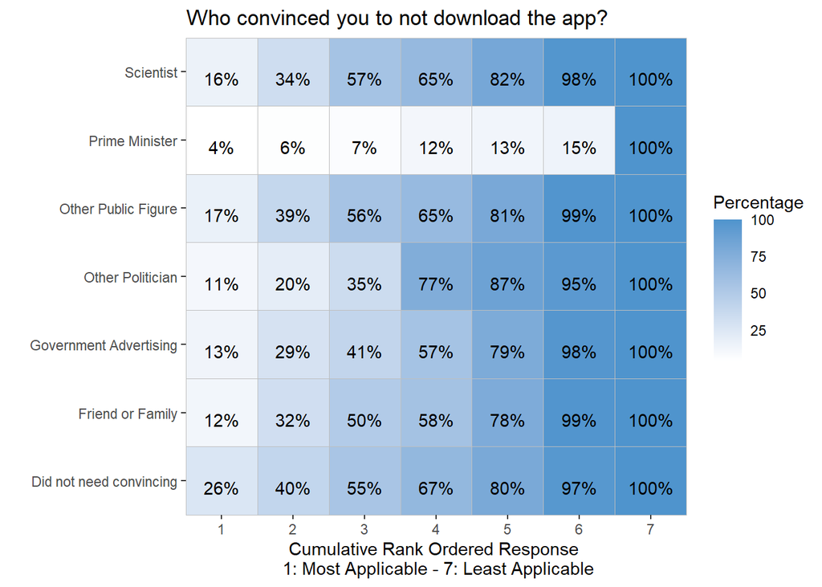

### COVIDSafe - Perceived Effectiveness, now and in the future

We next asked all participants the same set of general questions targeting the effectiveness of the COVIDSafe app. We asked participants to estimate the current percentage of Australians’ who are using the COVIDSafe app. When then asked participants to estimate the percentage of Australians’ who will be using the COVIDSafe app in the future. Results are displayed in the Figure below.

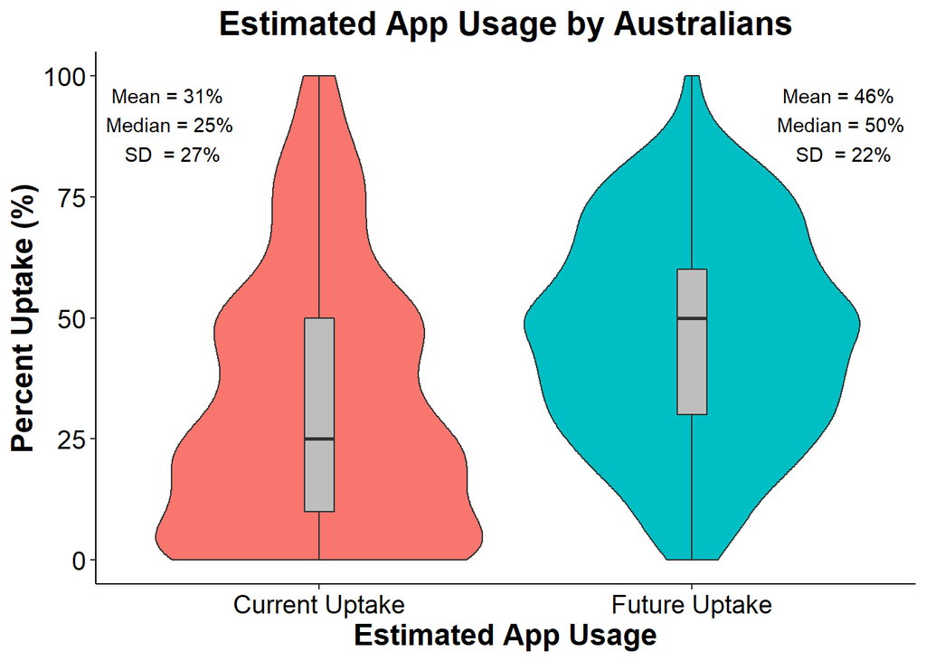

The effectiveness of the COVIDSafe app is in no small way linked to the belief that rapid app adoption will shorten the duration in which Australian remain in lockdown. When asked if the Government should use the COVIDSafe smartphone app uptake levels to decide on when restrictions should be lifted, 51% of participants responded yes.

In our previous work, participant responses were quite different to hypothetical scenarios when mobile phone tracking was voluntary vs mandatory. The COVIDSafe app is currently a voluntary download, however, it has been suggested the Government may consider making this app mandatory. We asked participants, if an insufficient number of Australians download the COVIDSafe smartphone app, should the government make downloading the app mandatory by issuing fines to those who do not comply? 77% of participants responded no.

Finally, we asked a series of questions about participant’s perception of the COVIDSafe app, now that they had read the app description and responded to several questions. These general items can be broken into two groups: assessing the efficacy of the app to impact the spread of COVID-19 & assessing the public’s understanding of the COVIDSafe app and their personal concerns about the app. Our questions regarding the app’s ability to impact the spread of COVID-19 include:

1. How confident are you that the app will reduce your likelihood of contracting COVID-19?
2. How confident are you that the app will help you resume your normal activities more rapidly?
3. How confident are you that the app will reduce the spread of COVID-19 in the community?
4. How confident are you that other people like yourself will be able to download and use the app effectively.

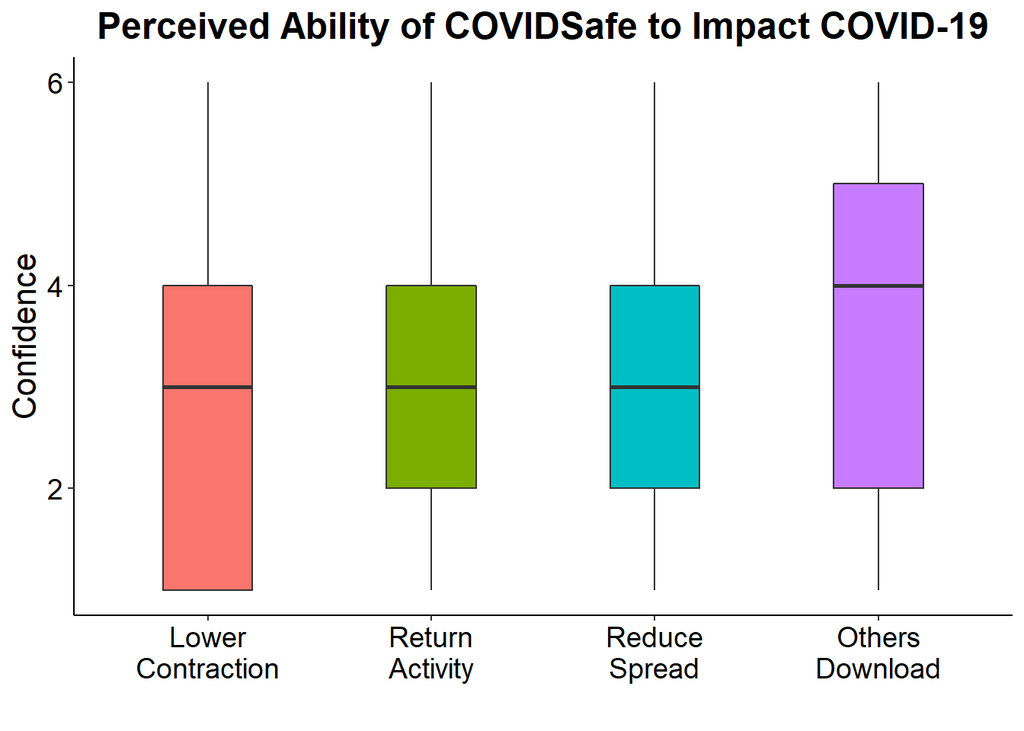

## COVIDSafe - Understanding of the app & personal concerns

Our questions regarding the public’s understanding of the COVIDSafe app and their personal concerns about the app included:

1. How easy is it for people to decline participation in COVIDSafe contact tracing?
2. To what extent is the Government only collecting the data necessary to achieve the purposes of the COVIDSafe app?
3. How sensitive is the data being collected by the COVIDSafe smartphone app?
4. How serious is the risk of harm that could arise from the COVIDSafe smartphone app?
5. How much do you trust the Government to use the COVIDSafe smartphone app data only to deal with the COVID-19 pandemic?
6. How much do you trust the Government to be able to ensure the privacy of each individual that uses the COVIDSafe smartphone app?
7. How secure is the data that is collected by the COVIDSafe smartphone app?
8. To what extent do people have ongoing control of their data from the COVIDSafe smartphone app?

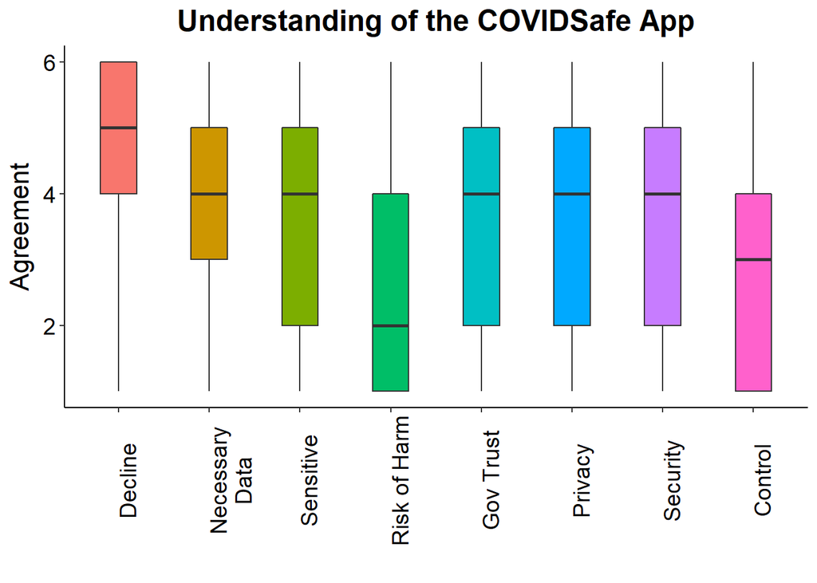

# Immunity Passports

The concept of an immunity passport - an electronic or physical identifier for those who have recovered from COVID-19 - is being considered by Government policymakers in Germany, Chile, Italy, China and Spain. The UK British Health Minister, Matt Hancock, went so far as to describe the document as “similar to a vaccination certificate”.

As of April May 5th 2020, no study has evaluated whether the presence of antibodies to SARS-CoV-2 - the virus that causes COVID-19 - confers immunity to subsequent infection by the virus in humans. To be clear, there is currently no evidence equating an immunity passport with a vaccination certificate, however, a mass study is currently underway in Germany to assess COVID-19 immunity after infection.

Antibody testing for COVID-19 is an important step in assessing and stoping the spread of COVID-19. While statistics often focus on current infections, many individuals present as asymptomatic and go undetected. The percentage of the population with COVID-19 antibodies provides an important metric of true infections & the true recovery rate. Antibody testing is currently playing a prominent role in the COVID-19 response in South Korea, Germany, and the United States of Ameria.

Although immunity passports present a means to rapidly re-open world economies, fears linger over the prospect of reinfection, a second outbreak, and the creation of a class-based economy. As those individuals with immunity passports return to work, go to gyms, gather at public events, and vist friends; those without will need to remain in lockdown to ensure healthcare systems do not become overun. The introduction of immunity passports raises another concern: will individuals seek to self-infect with COVID-19 to retun to normal activities sooner?

The concept of intential self-infeciton is not new, you or your parent may have attended a pre-vaccination chicken pox party as a child; however, the potential risks in catching chicken pox and COVID-19 are literally life-and-death. But maybe this is a risk young, healthy & immunocompetent individuals are willing to take?

The notion of whether immunity passports are ‘fair’ and their perceived effectiveness buy the public will dictate whether these temporary Government policies will be embraced. As protests occur against lockdown measures in the USA, Germany, Australia, and the UK, the allure of immunity passports may increase. Here, we ask a representative sample of 500 Australian’s about their attitudes to immunity passports as part of a Government response to COVID-19.

## Immunity Passports - an in-survey description

We began by presenting participants with this brief description of immunity passports, before asking questions about their attitudes towards their introduction in Australia.

“An ‘immunity passport’ indicates that you have had a disease and that you have the antibodies for the virus causing that disease. Having the antibodies implies that you are now immune and therefore unable to spread the virus to other people. Thus, if an antibody test indicates that you have had the disease, you could be allocated an ‘immunity passport’ which would subsequently allow you to move around freely. Immunity passports have been proposed as a potential step towards lifting movement restrictions during the COVID-19 pandemic.”

## Immunity Passports - The public’s response

Our questions regarding the public’s attitude towards immunity passpoarts included:

1. Would you support a government proposal to introduce ‘immunity passports’ for novel coronavirus (COVID-19)?
2. How concerned are you about the idea of introducing an ‘immunity passport’ for novel coronavirus (COVID-19)?
3. How much would you like to be allocated an ‘immunity passport’ for novel coronavirus (COVID-19)?
4. To what extent do you believe an ‘immunity passport’ for novel coronavirus (COVID-19) could harm the social fabric of your country?
5. To what extent do you believe that it is fair for people with ‘immunity passports’ for novel coronavirus (COVID-19) to go back to work, while individuals without such an ‘immunity passport’ cannot?
6. To what extent would you consider purposefully infecting yourself with novel coronavirus (COVID-19) to get an ‘immunity passport’ for novel coronavirus (COVID-19)?
7. Would you support a government proposal to introduce ‘immunity passports’ for novel coronavirus (COVID-19)?

Note, we ask whether participants support the introduction of an immunity passport twice: once before and once after answer questions about the policy. This provides an intial ‘gut reaction’ response and a follow up response after being force to consider the implications of this measure. Responses were made on a 6 point Likert scale with anchors ‘1 - Not at all’ and ‘6 - Extremely’. Results are as follows:

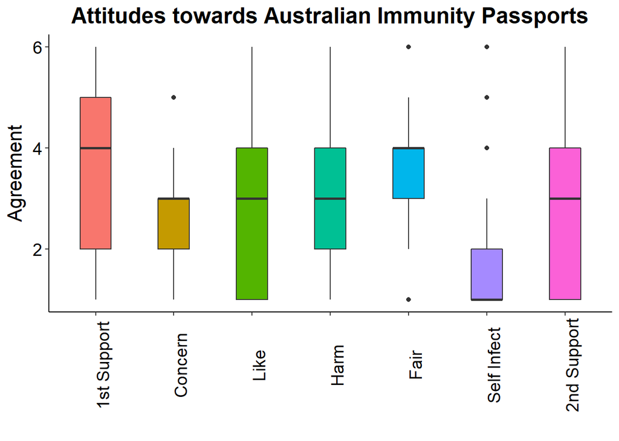

We next consider how these attitudes change across age ranges, and specifically, whether immunity passports appeal more to younger Australians who are less likely to be at risk from COVID-19 than older Australians.

Within all age brackets, support for immunity passports decreased between the first assessment (occuring just after participants read the text description; 1st support), and the second assessment (occuring just after participants answered the immunity passport questions; 2nd support).

We observe that Australians aged under 30 show generally stronger support for immunity passports, and that the degree of change in attitudes towards supporting immunity passports increased with age - older Australians appear to reflect more upon the questions and altered their intial oppinions.

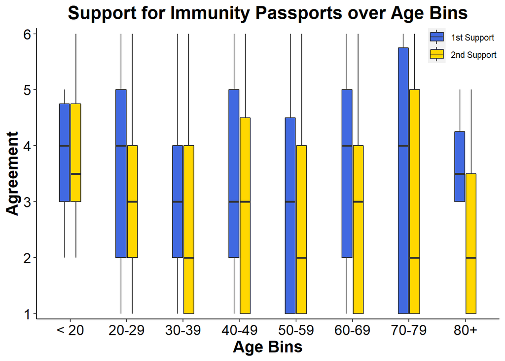

We now consider how attitidues towards our other measures change over age bins. Accross our other measures, we observe a slight decrease in concern over immunity passports as age increases, and a clear decrease in the likelihood of self infecting with COVID-19 as age increases. Risk of harm, fairness, and how much participants like immunity passports remain relatively stable across ages.

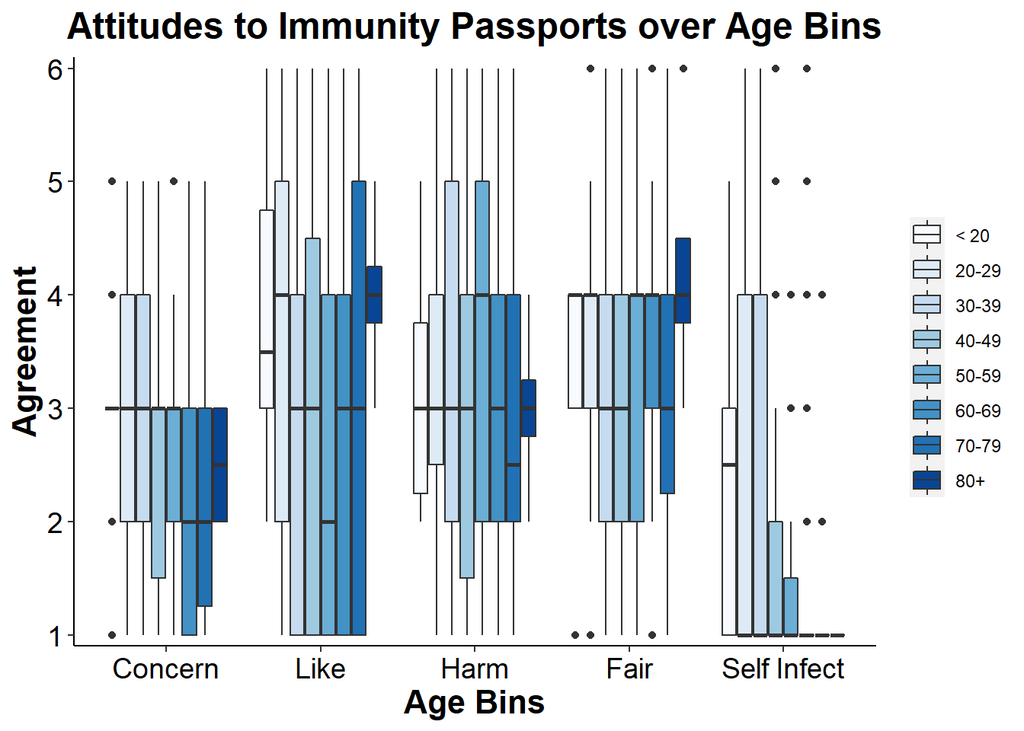

# Worldview & COVID-19

Finally, we assessed whether there was a correlation between the composite measures of three worldview items, to i) the perceived risk of COVID-19, and ii) the composite of two Government trust items. Results indicate no significant correlations between Worldview (interval depicts increasing libertarlianism) and the perceived risk of COVID-19 or the degree of Governmnet trust in Australia.

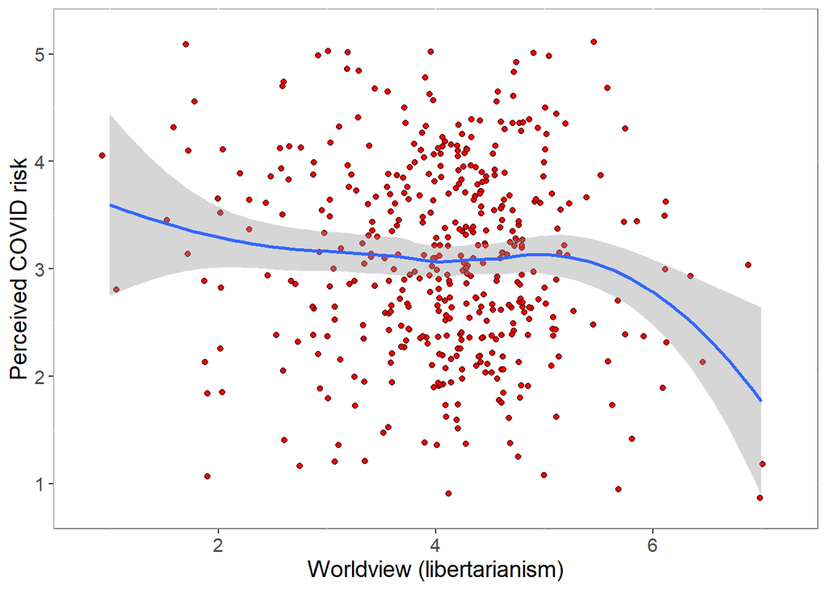

```
##
##  Pearson's product-moment correlation
##
## data:  Data$WorldView and Data$COVIDrisk
## t = -1.8924, df = 437, p-value = 0.0591
## alternative hypothesis: true correlation is not equal to 0
## 95 percent confidence interval:
##  -0.182209494  0.003463378
## sample estimates:
##         cor
## -0.09015639
```

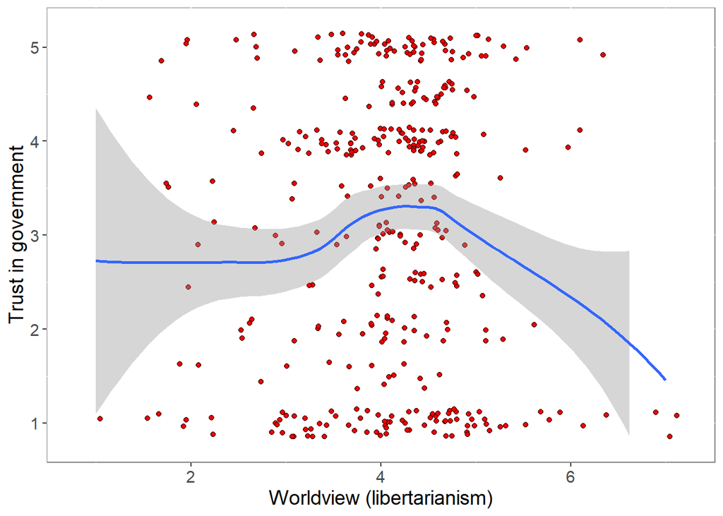

```
##
##  Pearson's product-moment correlation
##
## data:  Data$WorldView and Data$govtrust
## t = 0.55927, df = 437, p-value = 0.5763
## alternative hypothesis: true correlation is not equal to 0
## 95 percent confidence interval:
##  -0.06701416  0.12003423
## sample estimates:
##        cor
## 0.02674413
```

# References

Bonsall, D., Parker, M., Fraser, C. (2020).Sustainable containment of COVID-19 using smartphones in China: Scientific and ethical underpinnings for implementation of similar approaches in other settings.

The world health organization (WHO). WHO announces COVID-19 outbreak a pandemic. Retrieved from http://www.euro.who.int/en/health-topics/health-emergencies/coronavirus-covid-19/news/news/2020/3/who-announces-covid-19-outbreak-a-pandemic.

Wang, C. J., Ng, C. Y., & Brook, R. H. (2020). Response to COVID-19 in Taiwan: big data analytics, new technology, and proactive testing. JAMA.

Zhou, T., Liu, Q., Yang, Z., Liao, J., Yang, K., Bai, W., … & Zhang, W. (2020). Preliminary prediction of the basic reproduction number of the Wuhan novel coronavirus 2019-nCoV. Journal of Evidence-Based Medicine.